# Visualization Critique

MUNISA ABDUKARIMOVA

# Visualization Information

**Source:** Statista  
**Title:** Growth of the AI market worldwide from 2021 to 2031  
**URL:** https://www.statista.com/statistics/1602945/market-size-change-in-the-ai-market-worldwide/  
**Date Published:** July 1, 2025  
**Date Accessed:** 2025-11-10

# Visualization Description

The visualization from Statista displays the **market size change** (measured as percentage growth) in the artificial intelligence market worldwide from 2021 to 2031. According to the description:

- In 2024, the market size change was modeled at a certain percentage
- Between 2021 and 2024, the market size change dropped by several percentage points
- The market size change is expected to continue dropping through 2031
- The visualization shows a continuous downward trend in the **rate of growth** (not absolute market size)

[output not shown]

```
##
##
## The visualization typically shows a line or bar chart depicting
```

```
##
## the year-over-year percentage change in AI market size,
```

```
##
## demonstrating declining growth rates over time.
```

# Weakness

## What is the significant weakness?

The most significant weakness of this visualization is **the confusion between absolute market growth and rate of change**, which can mislead viewers into thinking the AI market is shrinking when it’s actually still growing—just at a slower pace. The visualization shows “market size change” as a percentage, which represents the **rate of growth**, not the actual market size. A declining percentage from, say, 40% growth to 20% growth still means the market is expanding, but viewers unfamiliar with these metrics may interpret the downward trend as market contraction.

## Why is this problematic?

This creates several interpretation issues:

1. **Cognitive disconnect:** Most audiences think of “market growth” as market expansion. Seeing a declining line graph triggers the mental association of “things getting worse,” when in reality, the market continues to grow substantially.
2. **Missing context:** The visualization doesn’t show the actual market size in dollars/euros, making it impossible to understand the real-world impact. A 20% growth rate on a $500 billion market is far more significant than a 40% growth rate on a $100 billion market.
3. **Baseline ambiguity:** Without showing the absolute values, viewers cannot assess whether the declining growth rate is due to market maturation (natural as markets grow larger) or actual slowdown in AI adoption.

## How could it be improved?

**Improvement Strategy 1: Dual-axis or dual-panel approach**

Create a visualization with two complementary components:

- **Panel A:** Absolute market size (in billions USD) over time, shown as bars or area chart
- **Panel B:** Year-over-year percentage growth rate, shown as a line graph

This allows viewers to see both stories: “The AI market continues to expand substantially” AND “The rate of expansion is moderating.”

**Improvement Strategy 2: Use compound visualization**

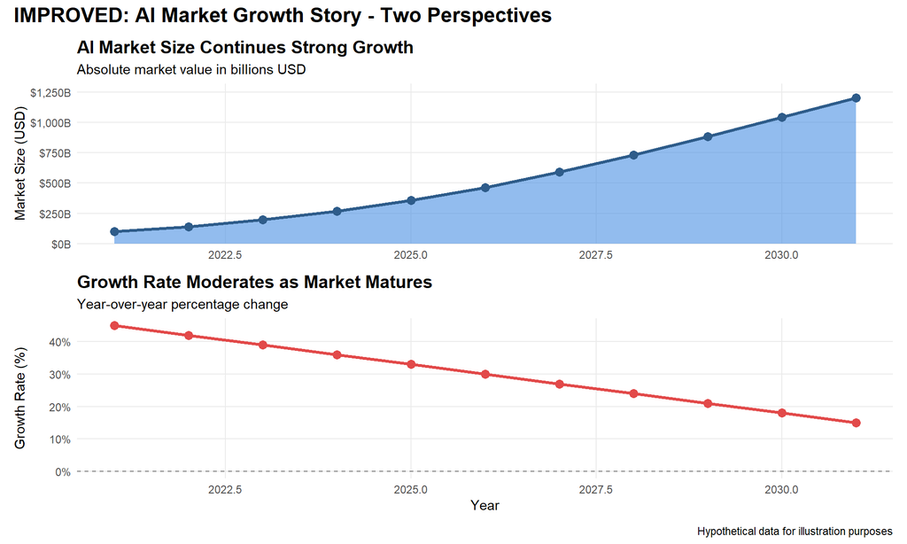

**Additional improvements:**

- Add **annotations** explaining that declining growth rates are normal for maturing markets
- Include **comparison benchmarks** (e.g., growth rates of other tech sectors)
- Provide **contextual information** about what’s driving the changes (market saturation, regulatory factors, etc.)

# Strength

## What is the strength of this visualization?

The primary strength of this visualization is its **focus on forward-looking projections through 2031**, which provides valuable strategic planning information for businesses, investors, and policymakers. By extending the timeline seven years into the future (from 2024 to 2031), the visualization goes beyond simple historical reporting to offer predictive insights.

## Why is this effective?

**Strategic Value:**

The multi-year projection enables:

1. **Trend identification:** Viewers can see that the slowdown in growth rate is not a temporary fluctuation but a sustained pattern, suggesting market maturation rather than a bubble burst.
2. **Planning horizon:** The 10-year window (2021-2031) provides sufficient time depth for:
   - **Investors:** Adjusting portfolio strategies and return expectations
   - **Companies:** Planning R&D investments and market entry timing
   - **Policymakers:** Developing appropriate regulatory frameworks
3. **Risk assessment:** The declining growth trajectory helps stakeholders calibrate expectations and avoid over-optimistic projections based on early-stage explosive growth.

**Design Choice that Enhances Impact:**

The inclusion of both historical data (2021-2024) and projections (2024-2031) in a **single continuous visualization** is particularly effective because:

- It establishes **credibility** by grounding predictions in observed trends
- It creates a **seamless narrative** showing the evolution from rapid early growth to steady maturation
- It allows viewers to **mentally extrapolate** and assess whether the projection seems reasonable based on the historical pattern

**Temporal Granularity:**

The year-by-year breakdown (rather than showing just 2021 and 2031) reveals the **pace and consistency** of the trend. This granular approach prevents viewers from drawing incorrect conclusions they might make from seeing only endpoints (e.g., assuming linear change when it’s actually curved).

## Additional Strength:

The visualization’s **clear temporal scope** (explicitly stating “from 2021 to 2031” in the title) immediately orients viewers and sets expectations about what they’re examining. This transparency about the time dimension is critical for interpreting growth metrics correctly.

# Overall Assessment

**Summary:** This visualization excels at providing forward-looking strategic insights through multi-year projections but suffers from potential misinterpretation due to its focus on growth rates rather than absolute values. The declining trend line can create unwarranted pessimism about the AI market when the underlying story is one of continued expansion at a moderating pace—a natural characteristic of maturing markets.

**Key Recommendation:** The visualization would be significantly more effective if paired with a companion chart showing absolute market size, transforming it from potentially misleading to genuinely insightful.

**Rating:** - **Clarity:** 6/10 - **Accuracy:** 7/10  
- **Strategic Value:** 9/10 - **Overall Effectiveness:** 7/10